# Using features of dynamic networks to guide treatment selection and outcome prediction

Additional Simulations (Revision 2): Node Count and Sparsity

Authors

Affiliations

Björn S. Siepe

University of Marburg

Matthias Kloft

University of Marburg

Fridtjof Petersen

University of Groningen

Yong Zhang

University of Groningen

Laura F. Bringmann

University of Groningen

Daniel W. Heck

University of Marburg

Published

May 7, 2026

# 1 Background

In this document, we combine the various files for the additional simulations with different sparsity settings and different number of nodes and analyze them together. Overall, the results are similar to the results of the main manuscript.

We think that our initial data-generating process (less sparsity than typically seen in simulation studies) is warranted for multiple reasons.

The data-generating network was chosen deliberately to reflect theoretical considerations about realistic psychological processes, rather than to match the conventions of previous simulation studies. We justify this choice on three grounds. Firstly, previous simulation studies have largely used sparse data-generating mechanisms, often based on chain graphs in which each node is connected only to the next one. While these structures are useful for their simplicity and ease of visualisation, they do not realistically represent the temporal interplay of, for example, affect or symptom variables. Notably, Hoekstra, Epskamp, and Borsboom (2022) used a contemporaneous and temporal network density of 62–63% in their empirically based condition, which is considerably denser than the sparse synthetic conditions used in the same paper. Empirical networks also appear sparse, but this likely reflects estimation constraints rather than the true data-generating structure. Most empirical studies combine limited per-person observations with regularisation methods or conservative variable selection procedures (as employed in mlVAR or GIMME), which necessarily produce sparse solutions. This has been demonstrated for cross-sectional networks by Epskamp, Kruis, and Marsman (2017), who showed that LASSO estimation almost always yields sparse structures at typical sample sizes, even when the true network is not sparse.

The problem is exacerbated in dynamic networks, which require the estimation of a temporal matrix with p² free parameters, in addition to the innovation covariance matrix, based on limited observations per person. In line with this, Mansueto et al. (2023) explicitly conclude that ‘sparsity is likely to be caused by low power and should not be interpreted as an actual lack of connections’, and simulation studies have confirmed that LASSO-based methods and GIMME strongly favour specificity over sensitivity (Nestler and Humberg 2021). Measurement error further exacerbates this issue by masking genuine non-zero relationships (Kankaanpää et al. 2026). Studies using larger sample sizes, such as O’Driscoll et al. (2022), yield considerably less sparse networks, supporting the interpretation that observed sparsity in idiographic research is largely an artefact of limited data and aggressive regularisation.

Theoretical considerations provide the primary justification for our design. Acyclic relations among closely related psychological constructs, such as affect items or symptom measures, are largely implausible from the perspective of network theory in psychopathology (Borsboom 2017) and dynamical systems research more broadly. Furthermore, enforcing sparsity in a network of psychological items implies rejecting a latent variable or common cause explanation (Epskamp, Kruis, and Marsman 2017), an assumption that many researchers would find difficult to justify for typical affect or symptom batteries. However, we note that the converse does not hold: a dense network of relatively weak connections does not entail a common cause structure.

# 2 Preparation

Load relevant packages:

```r
library(tidyverse)
library(SimDesign)
library(cowplot)
library(showtext)
library(sysfonts)
library(ggokabeito)
library(janitor)
library(ggh4x)
library(pander)
library(MetBrewer)
library(here)
library(lm.beta)

source(here::here("scripts", "00_functions.R"))
```

```r
revision <- "rev2"
use_rev <- TRUE
```

We then load the simulation results. Due to the computational complexity of the simulation, these are spread across different files in `output\rev2`:

- `sim_full_rev2_additional_row1_raw.rds`: Results of the first row with 200 iterations for each method
- `sim_full_rev2_additional_no_bayes.rds`: Results of the second and third row with 200 iterations for the non-Bayesian methods
- `sim_full_rev2_additional_only_bayes.rds`: Results of the second and third row with 30 iterations for the Bayesian methods

```r
row1 <- readRDS(here::here("output", "rev2", "sim_full_rev2_additional_row1_raw.rds"))
no_bayes <- readRDS(here::here("output", "rev2", "sim_full_rev2_additional_no_bayes.rds"))
only_bayes <- readRDS(here::here("output", "rev2", "sim_full_rev2_additional_only_bayes.rds"))
```

We then combine these files into a single large file:

```r
# combine results for row 2 and 3 while ensuring that duplicate columns are named correctly
row23 <- no_bayes |>
  left_join(only_bayes, by = c("dgp", "n_id", "heterogeneity", "n_tp"),
            suffix = c("_no_bayes", "_only_bayes"))

# combine row 1 with rows 2 and 3
df_rev2 <- bind_rows(row1, row23)


# Create a cut version of the simulation results without MCMC diagnostics
sim_res_cut <- df_rev2 |>
  select(-contains("rhat")) |>
  select(-contains("divtrans"))
```

# 3 Data-Generating Processes

Here, we summarize the data-generating processes (DGPs) used in the simulations. We used three different DGPs with varying node counts and sparsity levels to assess the robustness of our findings across different network structures.

```r
# write matrix to LaTeX format for better visualization
write_matrix <- function(x) {
  begin <- "\\begin{bmatrix}\n"
  end <- "\\end{bmatrix}"
  # format numbers to 3 decimal places and collapse into LaTeX rows
  X <- apply(x, 1, function(x) paste(round(x, 3), collapse = " & "))
  paste0(begin, paste(X, collapse = " \\\\ \n"), "\n", end)
}

# DGP A: 6-node, high-sparsity (>70% off-diagonal zeroed)
graph_sparse_6n_highsparse <- readRDS(here::here("data", "graph_sparse_6n_highsparse.RDS"))

# DGP B: 10-node, original semi-sparse DGM
graph_semisparse_10n <- readRDS(here::here("data", "graph_semisparse_10n.RDS"))

# DGP C: 10-node, sparse DGM
graph_sparse_10n <- readRDS(here::here("data", "graph_sparse_10n.RDS"))
```

## 3.1 First data-generating process (6 nodes, higher sparsity):

VAR matrix:
$$\begin{bmatrix}
0.392 & 0.096 & 0 & 0 & 0.096 & 0 \\
0 & 0.35 & 0 & 0 & 0.075 & 0 \\
0.096 & 0 & 0.35 & 0 & 0 & 0 \\
0 & 0 & 0 & 0.35 & 0 & 0 \\
0 & 0 & 0 & 0 & 0.35 & 0 \\
0.096 & 0 & 0 & 0 & 0 & 0.35
\end{bmatrix}$$
Innovation covariance matrix:
$$\begin{bmatrix}
1 & 0 & 0.165 & 0 & 0.165 & 0 \\
0 & 1 & 0 & 0 & 0 & 0 \\
0.165 & 0 & 1 & 0 & 0 & 0 \\
0 & 0 & 0 & 1 & 0 & 0 \\
0.165 & 0 & 0 & 0 & 1 & 0 \\
0 & 0 & 0 & 0 & 0 & 1
\end{bmatrix}$$

## 3.2 Second data-generating process (10 nodes, medium sparsity):

VAR matrix:

$$\begin{bmatrix}
0.401 & 0.101 & 0.101 & 0.101 & 0.101 & 0.101 & 0.101 & 0.101 & 0.101 & 0.101 \\
0.101 & 0.35 & 0.075 & 0.075 & 0.075 & 0 & 0.075 & 0.075 & 0.075 & 0.075 \\
0.101 & 0.075 & 0.35 & 0.075 & 0.075 & 0.075 & 0 & 0.075 & 0.075 & 0.075 \\
0.101 & 0 & 0.075 & 0.35 & 0.075 & 0 & 0.075 & 0 & 0.075 & 0.075 \\
0.101 & 0.075 & 0.075 & 0 & 0.35 & 0.075 & 0.075 & 0.075 & 0 & 0 \\
0.101 & 0.075 & 0 & 0.075 & 0 & 0.35 & 0.075 & 0.075 & 0.075 & 0.075 \\
0.101 & 0.075 & 0.075 & 0.075 & 0 & 0.075 & 0.35 & 0.075 & 0.075 & 0 \\
0.101 & 0.075 & 0.075 & 0.075 & 0.075 & 0.075 & 0.075 & 0.35 & 0.075 & 0.075 \\
0.101 & 0.075 & 0.075 & 0 & 0.075 & 0.075 & 0.075 & 0 & 0.35 & 0.075 \\
0.101 & 0 & 0.075 & 0.075 & 0.075 & 0.075 & 0.075 & 0.075 & 0.075 & 0.35
\end{bmatrix}$$
Innovation covariance matrix:
$$\begin{bmatrix}
1 & 0.188 & 0.188 & 0.188 & 0.188 & 0.188 & 0.188 & 0.188 & 0.188 & 0.188 \\
0.188 & 1 & 0 & 0.15 & 0.15 & 0 & 0.15 & 0 & 0.15 & 0.15 \\
0.188 & 0 & 1 & 0.15 & 0.15 & 0.15 & 0.15 & 0.15 & 0 & 0.15 \\
0.188 & 0.15 & 0.15 & 1 & 0.15 & 0 & 0.15 & 0.15 & 0.15 & 0.15 \\
0.188 & 0.15 & 0.15 & 0.15 & 1 & 0.15 & 0 & 0.15 & 0 & 0.15 \\
0.188 & 0 & 0.15 & 0 & 0.15 & 1 & 0.15 & 0.15 & 0.15 & 0.15 \\
0.188 & 0.15 & 0.15 & 0.15 & 0 & 0.15 & 1 & 0.15 & 0.15 & 0.15 \\
0.188 & 0 & 0.15 & 0.15 & 0.15 & 0.15 & 0.15 & 1 & 0.15 & 0.15 \\
0.188 & 0.15 & 0 & 0.15 & 0 & 0.15 & 0.15 & 0.15 & 1 & 0 \\
0.188 & 0.15 & 0.15 & 0.15 & 0.15 & 0.15 & 0.15 & 0.15 & 0 & 1
\end{bmatrix}$$

## 3.3 Third data-generating process (10 nodes, higher sparsity):

VAR matrix:

$$\begin{bmatrix}
0.386 & 0 & 0 & 0.093 & 0 & 0 & 0 & 0 & 0 & 0 \\
0.093 & 0.35 & 0 & 0 & 0 & 0 & 0 & 0 & 0.075 & 0.075 \\
0.093 & 0 & 0.35 & 0 & 0.075 & 0 & 0 & 0 & 0.075 & 0.075 \\
0.093 & 0.075 & 0 & 0.35 & 0 & 0 & 0 & 0 & 0 & 0 \\
0.093 & 0 & 0 & 0 & 0.35 & 0 & 0 & 0 & 0 & 0 \\
0 & 0.075 & 0 & 0 & 0 & 0.35 & 0 & 0.075 & 0 & 0 \\
0 & 0 & 0 & 0 & 0 & 0 & 0.35 & 0 & 0 & 0.075 \\
0 & 0 & 0 & 0 & 0 & 0 & 0 & 0.35 & 0 & 0.075 \\
0.093 & 0 & 0 & 0.075 & 0 & 0.075 & 0 & 0 & 0.35 & 0 \\
0 & 0 & 0 & 0 & 0 & 0.075 & 0.075 & 0 & 0 & 0.35
\end{bmatrix}$$
Innovation covariance matrix:
$$\begin{bmatrix}
1 & 0.167 & 0.167 & 0 & 0 & 0 & 0 & 0.167 & 0.167 & 0 \\
0.167 & 1 & 0.15 & 0 & 0 & 0 & 0 & 0 & 0 & 0 \\
0.167 & 0.15 & 1 & 0 & 0 & 0 & 0 & 0 & 0 & 0 \\
0 & 0 & 0 & 1 & 0 & 0 & 0.15 & 0.15 & 0 & 0 \\
0 & 0 & 0 & 0 & 1 & 0 & 0 & 0 & 0.15 & 0 \\
0 & 0 & 0 & 0 & 0 & 1 & 0 & 0 & 0.15 & 0.15 \\
0 & 0 & 0 & 0.15 & 0 & 0 & 1 & 0 & 0 & 0 \\
0.167 & 0 & 0 & 0.15 & 0 & 0 & 0 & 1 & 0 & 0 \\
0.167 & 0 & 0 & 0 & 0.15 & 0.15 & 0 & 0 & 1 & 0 \\
0 & 0 & 0 & 0 & 0 & 0.15 & 0 & 0 & 0 & 1
\end{bmatrix}$$

# 4 Data Wrangling

Prepare dataframe for visualization by giving proper names, removing unnecessary columns, and pivoting longer. We also remove columns that contain standard deviations of the strength measures.

```r
sr_edit <- sim_res_cut |>
  mutate(
    n_tp = factor(n_tp, levels = c(120)),
    n_id = factor(n_id, levels = c(75)),
    dgp = case_when(
      dgp == "sparse_6n_highsparse" ~ "Sparse (6 nodes, high sparsity)",
      dgp == "semisparse_10n" ~ "Semi-sparse (10 nodes, medium sparsity)",
      dgp == "sparse_10n" ~ "Sparse (10 nodes, high sparsity)",
      .default = dgp
    )
    ) |>
  # turn dgp into factor for correct ordering
  mutate(dgp = factor(dgp, levels = c(
    "Sparse (6 nodes, high sparsity)",
    "Semi-sparse (10 nodes, medium sparsity)",
    "Sparse (10 nodes, high sparsity)"
  ))) |>


  # remove "reg_" from all column names
  rename_with(~str_remove(., "reg_")) |>
  # remove everything before a "." in the column names
  rename_with(~str_remove(., ".*\\.")) |>
  dplyr::select(!matches("REPLICATIONS|SIM_TIME|SEED|COMPLETED|WARNINGS")) |>
  dplyr::select(!matches("strength_sd|instrength_sd|outstrength_sd")) |>
  dplyr::select(-c("heterogeneity")) |>
  # pivot longer except conditions cols
  pivot_longer(cols = -c("dgp", "n_tp", "n_id"),
               names_to = "measure",
               values_to = "value") |>
  mutate(measure = str_replace(measure, "power_reg", "powerreg"),
         measure = str_replace(measure, "powertwoside_reg", "powertwosidereg"),
         measure = str_replace(measure, "poweroneside_reg", "poweronesidereg"),
         measure = str_replace(measure, "rmse_reg", "rmsereg"),
         measure = str_replace(measure, "bias_reg", "biasreg"),
         measure = str_replace(measure, "mse_reg", "msereg")) |>
  separate_wider_delim(measure,
                       delim = "_",
                       names = c("pm", "outcome", "method", "summary")) |>
  mutate(method = case_when(
    method == "gvar" ~ "GVAR",
    method == "gimme" ~ "GIMME",
    method == "mlvar" ~ "mlVAR",
    method == "bmlvar" ~ "BmlVAR"
  )) |>
  # treat method as factor and order
  mutate(method = factor(method, levels = c("GVAR", "GIMME", "mlVAR", "BmlVAR"))) |>
  mutate(outcome = case_when(
    outcome == "beta" ~ "Temporal",
    outcome == "pcor" ~ "Contemporaneous",
    .default = outcome
  )) |>
  group_by(dgp, n_tp, n_id, pm, outcome, method) |>
  pivot_wider(names_from = summary, values_from = value) |>
  ungroup()
```

Prepare different colors and settings for visualization:

```r
meth_colors <- set_names(MetBrewer::met.brewer("Johnson")[c(1,2,4,5)],
                         c("GVAR", "mlVAR", "GIMME", "BmlVAR"))
```

# 5 Warnings and Errors

Here, we focus on the warnings and errors that occurred during the simulation. Unfortunately, warnings of the first row were not saved. We here present warnings and errors of the second and third row, which were saved separately for Bayesian and non-Bayesian methods.

```r
# extract warnings and errors for non-Bayesian methods
no_bayes <- readRDS(here::here("output", "rev2", "sim_full_rev2_additional_no_bayes.rds"))
only_bayes <- readRDS(here::here("output", "rev2", "sim_full_rev2_additional_only_bayes.rds"))

# get warning
no_bayes_warnings <- SimExtract(no_bayes, what = "warnings")
only_bayes_warnings <- SimExtract(only_bayes, what = "warnings")
```

Print warnings for non-Bayesian methods:

```r
# convert into readable format
no_bayes_warnings |>
  dplyr::select(!c(strength_sd, outstrength_sd, instrength_sd)) |>
  pivot_longer(cols = !c(dgp, n_id, heterogeneity, n_tp)) |>
  select(name, value) |>
  knitr::kable()
```

| name | value |
| --- | --- |
| WARNING: c(“Warning in NULL : `funs()` was deprecated in dplyr 0.8.0.”, “Warning in NULL : Please use a list of either functions or lambdas: # Simple nam | 30 |
| WARNING: Warning in Rothmana(data_l, data_c, lambdas$beta[i], lambdas$kappa[i], regularize_mat_beta = regularize_mat_beta, regularize_mat_kappa = regulariz | 117283 |
| WARNING: c(“Warning in NULL : `funs()` was deprecated in dplyr 0.8.0.”, “Warning in NULL : Please use a list of either functions or lambdas: # Simple nam | 0 |
| WARNING: Warning in Rothmana(data_l, data_c, lambdas$beta[i], lambdas$kappa[i], regularize_mat_beta = regularize_mat_beta, regularize_mat_kappa = regulariz | 1 |

Print warnings for Bayesian methods:

```r
only_bayes_warnings |>
  # remove all line breaks to make table more readable
  mutate(across(everything(), ~ str_replace_all(.x, "[\n]", " "))) |>
  dplyr::select(!c(strength_sd, outstrength_sd, instrength_sd)) |>
  pivot_longer(cols = !c(dgp, n_id, heterogeneity, n_tp)) |>
  mutate(name = gsub("WARNING:  Warning in NULL :", "", name)) |>
  mutate(name = gsub("\n", "", name)) |>
  select(name, value) |>
  filter(value > 0 ) |>
  knitr::kable()
```

| name | value |
| --- | --- |
| Bulk Effective Samples Size (ESS) is too low, indicating posterior means and medians may be unreliable.Running the chains for more i | 14 |
| Examine the pairs() plot to diagnose sampling problems | 2 |
| Tail Effective Samples Size (ESS) is too low, indicating posterior variances and tail quantiles may be unreliable.Running the chains | 15 |
| There were 19 divergent transitions after warmup. Seehttps://mc-stan.org/misc/warnings.html#divergent-transitions-after-warmupto fin | 2 |
| Bulk Effective Samples Size (ESS) is too low, indicating posterior means and medians may be unreliable.Running the chains for more i | 15 |
| Examine the pairs() plot to diagnose sampling problems | 6 |
| Tail Effective Samples Size (ESS) is too low, indicating posterior variances and tail quantiles may be unreliable.Running the chains | 15 |
| There were 19 divergent transitions after warmup. Seehttps://mc-stan.org/misc/warnings.html#divergent-transitions-after-warmupto fin | 6 |
| The largest R-hat is NA, indicating chains have not mixed.Running the chains for more iterations may help. Seehttps://mc-stan.org/mi | 2 |
| There were 500 transitions after warmup that exceeded the maximum treedepth. Increase max_treedepth above 10. Seehttps://mc-stan.org | 1 |
| WARNING: Warning in validityMethod(object) : The following variables have undefined values: reg_intercept_z[1],The following variables have undefined values: | 7 |

# 6 Point Estimates

Plot point estimate recovery as mean squared error (MSE) which is helpful to understand the overall performance of the different methods.

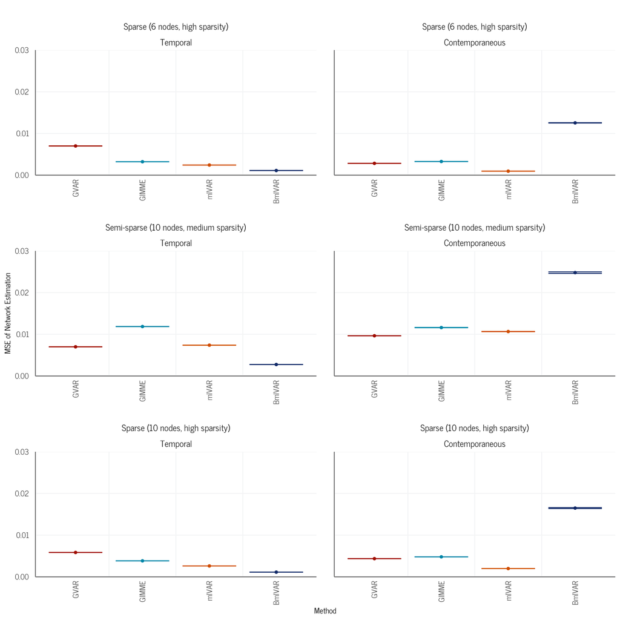

```r
plot_mse <- sr_edit |>
  mutate(mcse = ifelse(is.na(mcse), 0, mcse)) |>
  mutate(outcome = factor(outcome, levels = c("Temporal", "Contemporaneous"))) |>
  filter(pm == "mse") |>
  ggplot(aes(x = method,
             y = mean,
             colour = method
             )) +
  # add vertical line between methods
  geom_vline(colour = "#F3F4F5", xintercept = seq(1.5, 4, 1))+
  geom_errorbar(aes(ymin = mean - 1*mcse,
                            ymax = mean + 1*mcse),
                        width = .8,
                 position = position_dodge(0.7),
                 show.legend = FALSE)+
  geom_point(position = position_dodge(0.7),
             size = 1.2) +
  ggh4x::facet_wrap2(dgp ~ outcome,
                      axes = "all",
                      remove_labels = "y", nrow = 3) +
  scale_x_discrete(guide = guide_axis(angle = 90))+
  scale_y_continuous(expand = c(0, 0), limits = c(0,0.03)) +
  scale_color_manual(values = meth_colors) +
  theme_centrality()+
  theme(legend.position = "none",
        text = element_text(size = 22))+
  labs(title = "",
       x = "Method",
       colour = "Method",
       y = "MSE of Network Estimation")

plot_mse
```

Plot Bias:

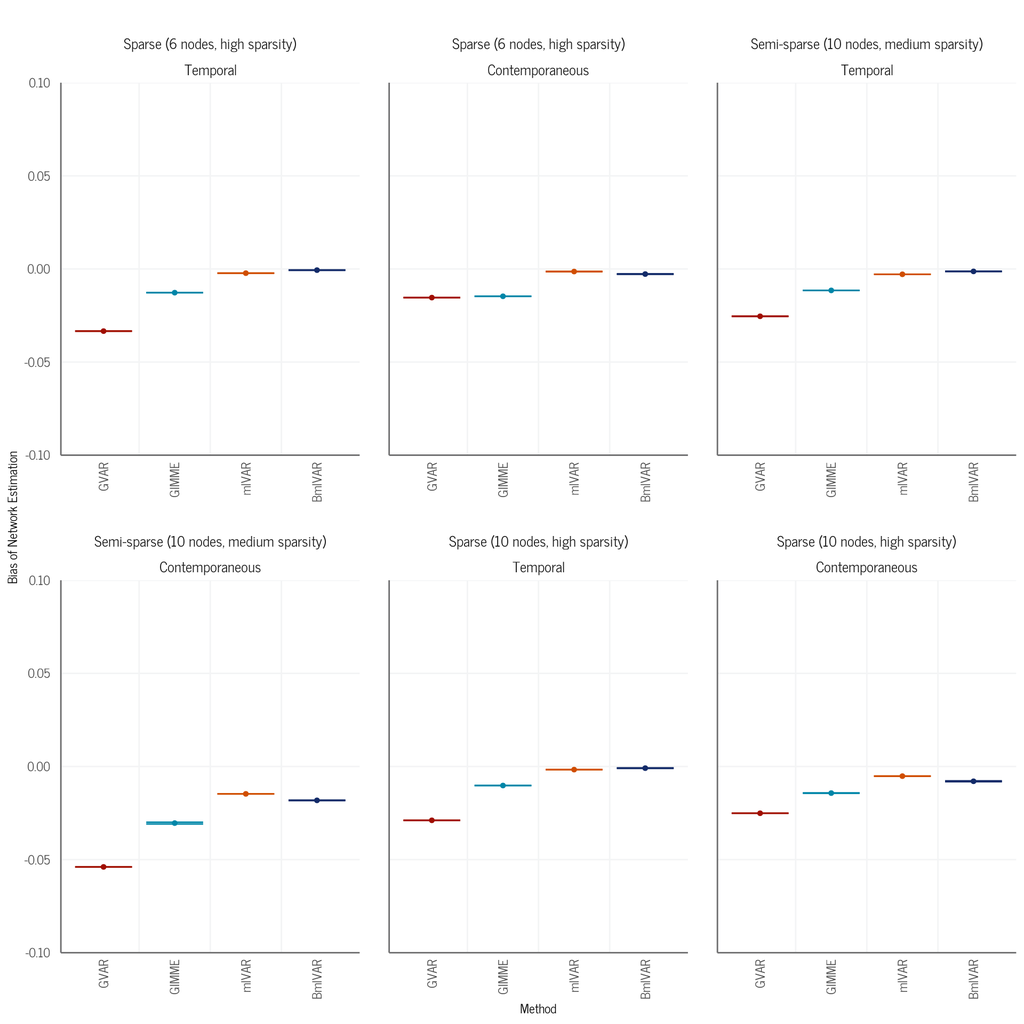

```r
plot_bias <- sr_edit |>
  mutate(mcse = ifelse(is.na(mcse), 0, mcse)) |>
  mutate(outcome = factor(outcome, levels = c("Temporal", "Contemporaneous"))) |>
  filter(pm == "bias") |>
  ggplot(aes(x = method,
             y = mean,
             colour = method
             )) +
  # add vertical line between methods
  geom_vline(colour = "#F3F4F5", xintercept = seq(1.5, 4, 1))+
  geom_errorbar(aes(ymin = mean - 1*mcse,
                            ymax = mean + 1*mcse),
                        width = .8,
                 position = position_dodge(0.7),
                 show.legend = FALSE)+
  geom_point(position = position_dodge(0.7),
             size = 1.2) +
  ggh4x::facet_wrap2(dgp ~ outcome,
                      axes = "all",
                      remove_labels = "y") +
  scale_x_discrete(guide = guide_axis(angle = 90))+
  scale_y_continuous(expand = c(0, 0), limits = c(-0.1,0.1)) +
  scale_color_manual(values = meth_colors) +
  theme_centrality() +
  theme(legend.position = "none",
        text = element_text(size = 22))+
  labs(title = "",
       x = "Method",
       colour = "Method",
       y = "Bias of Network Estimation")

plot_bias
```

# 7 Centrality

## 7.1 Plot most central identical

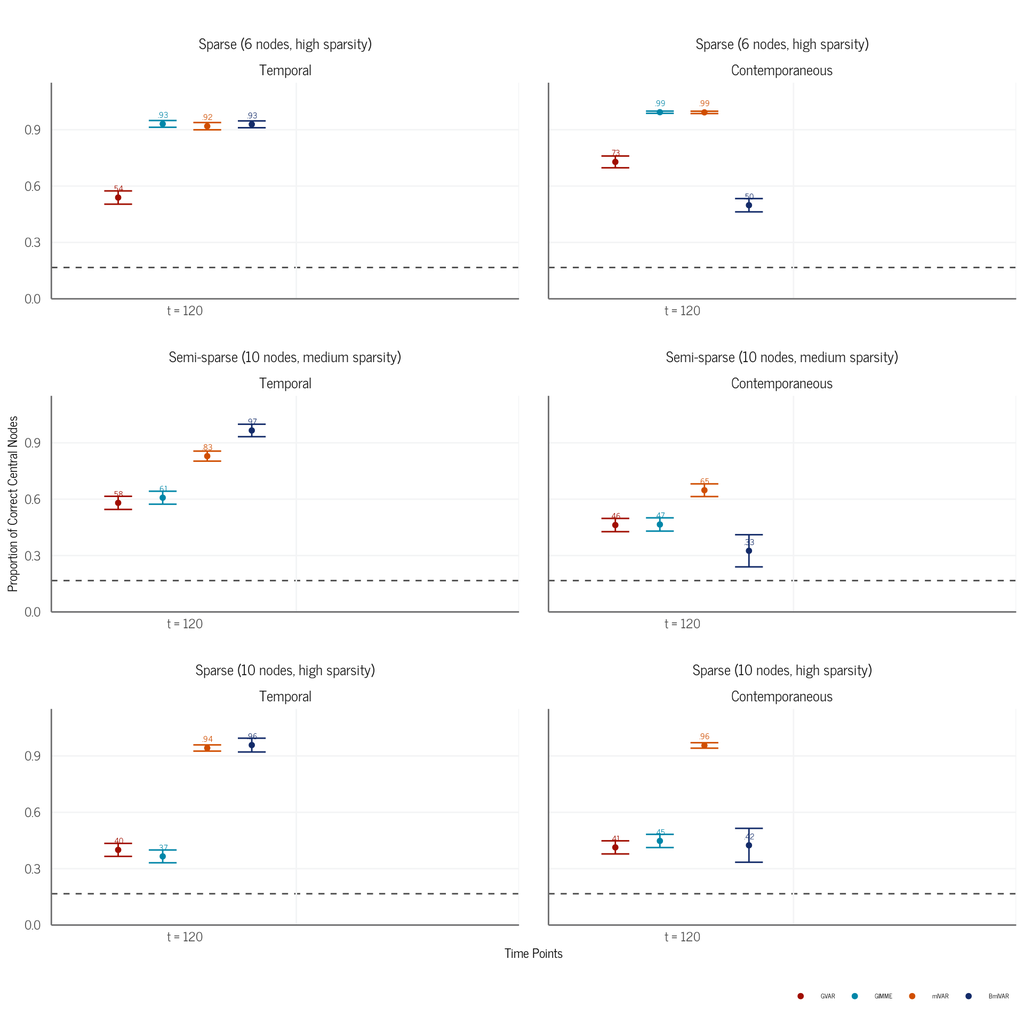

```r
plot_mostcentral <- sr_edit |>
  # if mcse is missing, set to 0
  mutate(mcse = ifelse(is.na(mcse), 0, mcse)) |>
  mutate(outcome = factor(outcome, levels = c("Temporal", "Contemporaneous"))) |>
  filter(pm == "mostcent") |>
  mutate(n_tp = paste0("t = ", n_tp)) |>
  mutate(n_tp = factor(n_tp, levels = c("t = 120"))) |>
  mutate(n_id = paste0("n = ", n_id)) |>
  mutate(n_id = factor(n_id, levels = c("n = 75"))) |>
  ggplot(aes(x = as.factor(n_tp),
             y = mean,
             group = method,
             colour = method
             )) +
  # horizontal line at chance level of 1/6
  geom_hline(yintercept = 1/6,
             linetype = 2,
             alpha = .7)+
  # add vertical line between methods
  geom_vline(colour = "#F3F4F5", xintercept = seq(1.5, 3, 1))+
  geom_errorbar(aes(ymin = mean - 1*mcse,
                            ymax = mean + 1*mcse),
                        width = .5,
                 position = position_dodge(0.8),
                 show.legend = FALSE)+
  geom_point(position = position_dodge(0.8),
             size = 1.4) +
  # add mean as text above errorbar
    geom_text(aes(label = sub("^(-?)0.", "\\1.",sprintf("%.2f", mean))),
              position = position_dodge(0.8),
              vjust = -1.0,
              size = 4,
              show.legend = FALSE) +
  ggh4x::facet_wrap2(dgp ~ outcome,
                      axes = "all",
                      remove_labels = "y",
               nrow = 3) +
  # scale_x_discrete(guide = guide_axis(angle = 90))+
  scale_y_continuous(expand = c(0, 0), limits = c(0,1.15)) +
  scale_color_manual(values = meth_colors) +
  theme_centrality() +
  theme(legend.position = "bottom",
        title = element_text(size = 27)
        )+
  labs(title = "",
       x = "Time Points",
       colour = "",
       y = "Proportion of Correct Central Nodes")

ggsave_rev("plot_mostcentral.pdf", plot_mostcentral, height = 6 * 1.1, width = 9 * 1.1,
       path = here::here("figures"), device = "pdf")

plot_mostcentral
```

## 7.2 Plot rank correlation of centrality measures

We were interested in the performance of centrality estimation, which we assessed with regard to rank-order performance. As we expected centrality estimates to be biased downwards in some methods due to sparsity assumptions, we computed the rank-order consistency of individual centrality estimates. To do so, we computed the point estimate of network centrality $\hat{c}$ per individual in a data set, which ignored estimation uncertainty. We then estimated the Spearman rank correlation $\hat{\rho}_{i}$ in repetition $i$ of these estimates with the true network centrality $c$ and calculated its average across repetitions as:
$$\begin{align*}
\widehat{\rho} = \frac{\sum_{i=1}^{n_{\text{sim}}} \hat{\rho}_i}{n_{\text{sim}}}
\end{align*}$$
We calculated the MCSE of this correlation via bootstrapping.

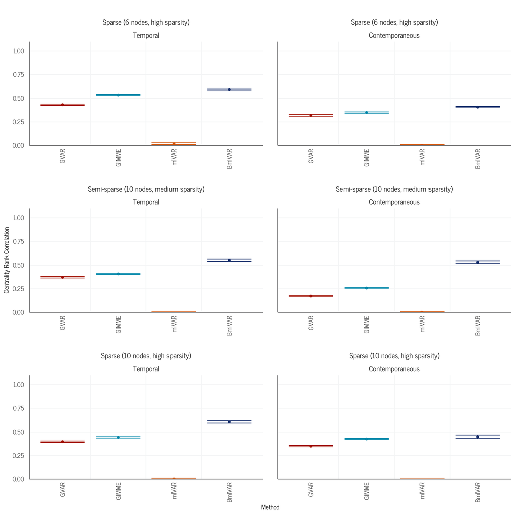

```r
plot_rankcor <- sr_edit |>
  # if mcse is missing, set to 0
  mutate(mcse = ifelse(is.na(mcse), 0, mcse)) |>
  # uselessly used temp and cont instead of beta and pcor here
  mutate(outcome = case_when(
    outcome == "temp" ~ "Temporal",
    outcome == "cont" ~ "Contemporaneous"
  )) |>
  mutate(outcome = factor(outcome, levels = c("Temporal", "Contemporaneous"))) |>
  filter(pm == "rankcor") |>
  ggplot(aes(x = method,
             y = mean,
             colour = method
             )) +
  # add vertical line between methods
  geom_vline(colour = "#F3F4F5", xintercept = seq(1.5, 4, 1))+
  geom_errorbar(aes(ymin = mean - 1*mcse,
                            ymax = mean + 1*mcse),
                        width = .8,
                 position = position_dodge(0.7),
                 show.legend = FALSE)+
  geom_point(position = position_dodge(0.7),
             size = 1.2) +
  ggh4x::facet_wrap2(dgp ~ outcome,
                      axes = "all",
                      remove_labels = "y", nrow = 3) +
  scale_x_discrete(guide = guide_axis(angle = 90))+
  scale_y_continuous(expand = c(0, 0), limits = c(0,1.1)) +
  scale_color_manual(values = meth_colors) +
  theme_centrality() +
  theme(legend.position = "none",
        text = element_text(size = 22))+
  labs(title = "",
       x = "Method",
       colour = "Method",
       y = "Centrality Rank Correlation")


ggsave_rev("plot_rankcor.pdf", plot_rankcor, height = 12, width = 16,
       path = here::here("figures/"), device = "pdf")

plot_rankcor
```

# 8 Regression

## 8.1 Power of Regression

### 8.1.1 In- and Outstrength combined

Prep data

```r
# Split data set into three based on true effect
power_df <- sr_edit |>
  filter(!str_detect(pm, "poweroneside")) |>
  mutate(pm = str_replace(pm, "powertwoside", "power")) |>
  filter(str_detect(pm, "power")) |>
  mutate(outcome = case_when(
    # outcome == "tempdens" ~ "Temporal\nDensity",
    # outcome == "contdens" ~ "Contemporaneous\nDensity",
    outcome == "outstrength" ~ "Temporal\nOutstrength",
    outcome == "strength" ~ "Contemporaneous\nStrength",
    outcome == "instrength" ~ "Temporal\nInstrength"
  )) |>
  # For now, remove contemporaneous strength
  filter(outcome != "Contemporaneous\nStrength") |>
  mutate(n_id = paste0("n = ", n_id)) |>
  mutate(n_id = factor(n_id, levels = c("n = 75"))) |>
  mutate(n_tp = paste0("t = ", n_tp)) |>
  mutate(n_tp = factor(n_tp, levels = c("t = 120"))) |>
  # split pm into two columns, take last number into new column
  separate_wider_delim(pm, delim = "reg", names = c("pm", "true_effect"))
```

Create the plot:

```r
# plot the power results
plot_power_combined <- ggplot(power_df, aes(x = n_tp,
                                            y = mean,
                                            colour = method,
                                            fill = method,
                                            group = method)) +
  # error bars using pooled mcse
  geom_errorbar(aes(ymin = mean - mcse,
                    ymax = mean + mcse),
                width = 0.5,
                position = position_dodge(0.7),
                show.legend = FALSE) +
  # background vertical grid lines
  geom_vline(colour = "#F3F4F5", xintercept = seq(1.5, 4, 1)) +
  geom_point(position = position_dodge(0.7),
             size = 1.4) +
  ggh4x::facet_wrap2(dgp ~ outcome,
                      axes = "all",
                      remove_labels = "y", nrow = 3) +
  scale_y_continuous(expand = c(0, 0), limits = c(-0.1, 1.1)) +
  scale_color_manual(values = meth_colors) +
  theme_centrality() +
  # global theme adjustments and legend activation
  theme(legend.position = "bottom",
        text = element_text(size = 25),
        strip.text = element_text(size = rel(0.85)),
        ggh4x.facet.nestline = element_line(colour = "#6d6d6e"),
        axis.text = element_text(size = 18)) +
  labs(title = "",
       x = "",
       colour = "Method",
       fill = "Method",
       y = "Detection Rate")

# saving output
ggsave_rev("plot_power_combined.pdf", plot_power_combined,
           height = 16 * 0.95, width = 16 * 0.8,
           path = here::here("figures/"))
```

How large was the difference between instrength and outstrength?

```r
power_df |>
  pivot_wider(id_cols = c(dgp, n_id, n_tp, pm, true_effect, method),
              names_from = outcome,
              values_from = c(mean, mcse)) |>
  filter(true_effect != 0) |>
  janitor::clean_names() |>
  mutate(mean_diff = mean_temporal_instrength - mean_temporal_outstrength) |>
  summarize(mean_mean_diff = mean(mean_diff)) |>
  knitr::kable()
```

| mean_mean_diff |
| --- |
| 0.0083333 |

## 8.2 Power and Bias for Outstrength

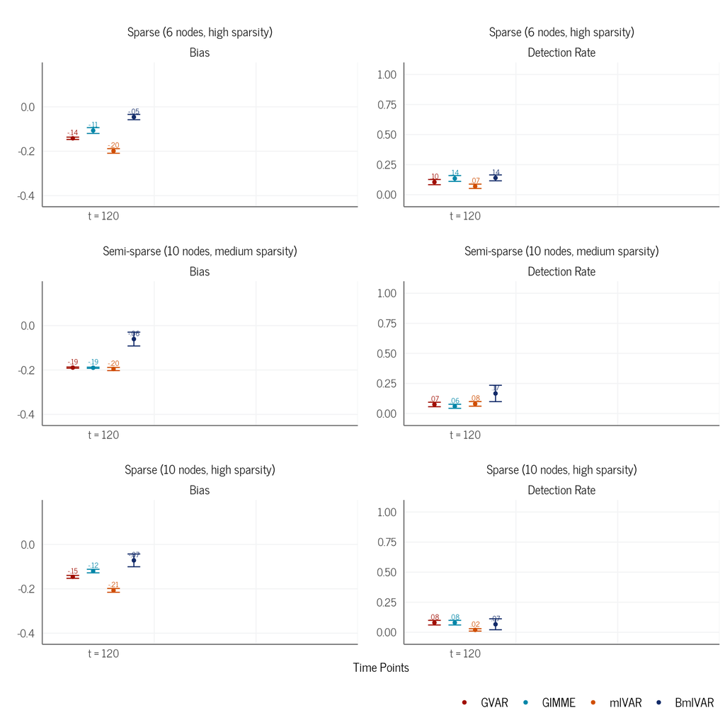

```r
power_bias_reg_combined_df <- sr_edit |>
  mutate(pm = str_replace(pm, "powertwoside", "power")) |>
  filter(!str_detect(pm, "poweroneside")) |>
  filter(str_detect(pm, "power") | str_detect(pm, "biasreg")) |>
    mutate(outcome = case_when(
    outcome == "outstrength" ~ "Temporal\nOutstrength",
    outcome == "strength" ~ "Contemporaneous\nStrength",
    outcome == "instrength" ~ "Temporal\nInstrength"
  )) |>
  filter(outcome == "Temporal\nOutstrength") |>
  mutate(n_id = paste0("n = ", n_id)) |>
  mutate(n_id = factor(n_id, levels = c("n = 75"))) |>
  mutate(n_tp = paste0("t = ", n_tp)) |>
  mutate(n_tp = factor(n_tp, levels = c("t = 120"))) |>
  # split pm into two columns, take last number into new column
  separate_wider_delim(pm, delim = "reg", names = c("pm", "true_effect")) |>
  mutate(method = factor(method, levels = c("GVAR", "GIMME", "mlVAR", "BmlVAR"))) |>
  mutate(true_effect = paste0("True Effect: .", true_effect)) |>
  mutate(pm = case_when(
    str_detect(pm, "power") ~ "Detection Rate",
    str_detect(pm, "bias") ~ "Bias"
  ))

plot_power_bias_outstrength <- power_bias_reg_combined_df |>
  ggplot(aes(x = n_tp,
             y = mean,
             colour = method,
             fill = method,
             group = method))+
  geom_errorbar(aes(ymin = mean - 1 * mcse,
                      ymax = mean + 1 * mcse),
                  width = 0.5,
                  position = position_dodge(0.8),
                  show.legend = FALSE) +
    # add vertical
    geom_vline(colour = "#F3F4F5", xintercept = seq(1.5, 4, 1))+
    geom_point(position = position_dodge(0.8),
               size = 1.4) +
    # add mean without leading zero
    geom_text(aes(label = sub("^(-?)0.", "\\1.",sprintf("%.2f", mean))),
              position = position_dodge(0.8),
              vjust = -0.6,
              size = 5,
              show.legend = FALSE) +
    ggh4x::facet_wrap2(dgp ~ pm,
                        axes = "all",
                        scales = "free_y",
                       nrow = 3) +
    facetted_pos_scales(
      y = list(pm == "Bias" ~ scale_y_continuous(expand = c(0, 0), limits = c(-.45, .2)),
               pm == "Detection Rate" ~ scale_y_continuous(expand = c(0, 0), limits = c(-0.1, 1.1)))
    )+
    labs(
      title = "",
      x = "Time Points",
      colour = "",
      fill = "",
      group = "",
      y = ""
    ) +
    scale_color_manual(values = meth_colors) +
    theme_centrality() +
    theme(legend.position = "bottom",
          ggh4x.facet.nestline = element_line(colour = "#6d6d6e"),
          axis.text.x = element_text(size = 22),
          axis.text.y = element_text(size = 22),
          axis.title.x = element_text(size = 24),
          # increase all legend element size
          legend.text = element_text(size = 24),
          legend.title = element_text(size = 24),
          legend.key.size = unit(1.6, "lines"),
          strip.text = ggplot2::element_text(size = 24),
          strip.text.x.top = ggplot2::element_text(size = 24)
          )

ggsave_rev("plot_power_bias_outstrength.pdf",
       plot_power_bias_outstrength, height = 16* 0.95, width = 16* 0.8,
       path = here::here("figures/"))

plot_power_bias_outstrength
```

## 8.3 Power and Bias for Contemporaneous Strength

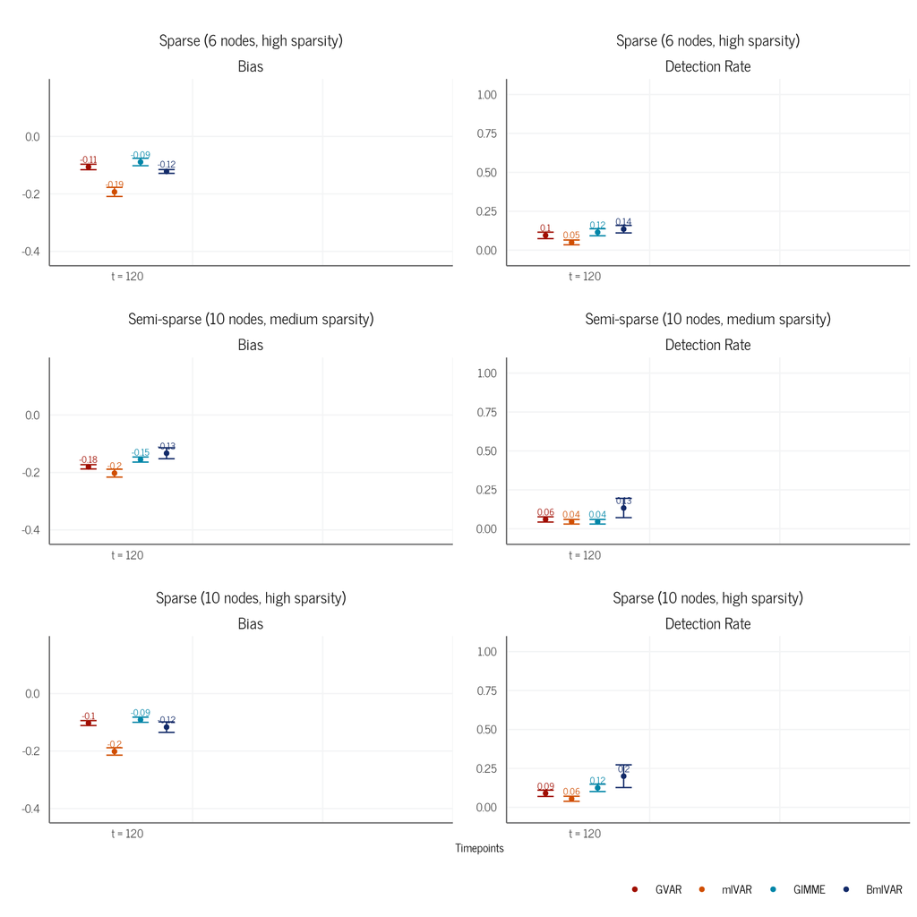

```r
power_bias_reg_strength_df <- sr_edit |>
  mutate(pm = str_replace(pm, "powertwoside", "power")) |>
  filter(!str_detect(pm, "poweroneside")) |>
  filter(str_detect(pm, "power") | str_detect(pm, "biasreg")) |>
    mutate(outcome = case_when(
    outcome == "outstrength" ~ "Temporal\nOutstrength",
    outcome == "strength" ~ "Contemporaneous\nStrength",
    outcome == "instrength" ~ "Temporal\nInstrength"
  )) |>
  filter(outcome == "Contemporaneous\nStrength") |>
  mutate(n_id = paste0("n = ", n_id)) |>
  mutate(n_id = factor(n_id, levels = c("n = 75"))) |>
  mutate(n_tp = paste0("t = ", n_tp)) |>
  mutate(n_tp = factor(n_tp, levels = c("t = 120"))) |>
  # split pm into two columns, take last number into new column
  separate_wider_delim(pm, delim = "reg", names = c("pm", "true_effect")) |>
  mutate(method = factor(method, levels = c("GVAR", "mlVAR", "GIMME", "BmlVAR"))) |>
  mutate(true_effect = paste0("True Effect: .", true_effect)) |>
  mutate(pm = case_when(
    str_detect(pm, "power") ~ "Detection Rate",
    str_detect(pm, "bias") ~ "Bias"
  ))

plot_power_bias_strength <- power_bias_reg_strength_df |>
  ggplot(aes(x = n_tp,
             y = mean,
             colour = method,
             fill = method,
             group = method))+
  geom_errorbar(aes(ymin = mean - 1 * mcse,
                      ymax = mean + 1 * mcse),
                  width = 0.5,
                  position = position_dodge(0.8),
                  show.legend = FALSE) +
    # add vertical
    geom_vline(colour = "#F3F4F5", xintercept = seq(1.5, 4, 1))+
    geom_point(position = position_dodge(0.8),
               size = 1.4) +
    # add mean as text above errorbar
    geom_text(aes(label = round(mean, 2)),
              position = position_dodge(0.8),
              vjust = -0.6,
              size = 5,
              show.legend = FALSE) +
    ggh4x::facet_wrap2(dgp ~ pm,
                        axes = "all",
                        scales = "free_y",
                       nrow = 3) +
    facetted_pos_scales(
      y = list(pm == "Bias" ~ scale_y_continuous(expand = c(0, 0), limits = c(-.45, .2)),
               pm == "Detection Rate" ~ scale_y_continuous(expand = c(0, 0), limits = c(-0.1, 1.1)))
    )+
    labs(
      title = "",
      x = "Timepoints",
      colour = "",
      fill = "",
      group = "",
      y = ""
    ) +
    scale_color_manual(values = meth_colors) +
    theme_centrality() +
    theme(legend.position = "bottom",
          ggh4x.facet.nestline = element_line(colour = "#6d6d6e"),
          axis.text = element_text(size = 18),
          # increase all legend element size
          legend.text = element_text(size = 18),
          legend.title = element_text(size = 18),
          legend.key.size = unit(1.5, "lines"),
          strip.text = ggplot2::element_text(size = 24),
          strip.text.x.top = ggplot2::element_text(size = 24)
          )

ggsave_rev("plot_power_bias_strength.pdf",
       plot_power_bias_strength, height = 16* 0.95, width = 16* 0.8,
       path = here::here("figures/"))

plot_power_bias_strength
```

## 8.4 RMSE and Bias of Regression

We create plot for different regression outcomes here:

```r
process_data <- function(data, summary) {
  df_clean <- data |>
    filter(str_detect(pm, summary)) |>
    mutate(outcome = case_when(
      outcome == "outstrength" ~ "Temporal\nOutstrength",
      outcome == "strength" ~ "Contemporaneous\nStrength",
      outcome == "instrength" ~ "Temporal\nInstrength"
    )) |>
    filter(outcome != "Contemporaneous\nStrength") |>
    mutate(
      n_id = factor(paste0("n = ", n_id), levels = c("n = 75")),
      n_tp = factor(paste0("t = ", n_tp), levels = c("t = 120"))
    ) |>
    separate_wider_delim(pm, delim = "reg", names = c("pm", "true_effect"))

    split(df_clean, df_clean$true_effect)
}

## Generic plotting function
create_regression_plot <- function(df,
                                   y_label) {
  ggplot(data = df,
         aes(
           x = n_tp,
           y = mean,
           colour = method,
           fill = method,
           group = method
         )) +
    # add horizontal dashed line at zero for bias
    geom_hline(yintercept = 0, linetype = 2, alpha = .4)+
    geom_errorbar(
      aes(ymin = mean - 1 * mcse, ymax = mean + 1 * mcse),
      width = .5,
      position = position_dodge(0.7),
      show.legend = FALSE
    ) +
    geom_point(position = position_dodge(0.7), size = 1.2) +
    ggh4x::facet_wrap2(dgp ~ outcome,
                        axes = "all",
                        remove_labels = "y",
                       nrow = 3) +
    scale_y_continuous(expand = c(0, 0), limits = c(-.25, .3)) +
    scale_color_manual(values = meth_colors) +
    theme_centrality() +
    theme(
      legend.position = "none",
      strip.text.x.top = ggplot2::element_text(size = rel(0.85)),
      ggh4x.facet.nestline = element_line(colour = "#6d6d6e"),
      axis.text = element_text(size = 18)
    ) +
    labs(
      title = "",
      x = "",
      colour = "",
      group = "",
      fill = "",
      y = y_label
    )
}

# Generate and save combined plots
generate_regression_plots <- function(data, summary, y_label, file_name) {
  processed_list <- process_data(data, summary)
  plot_list <- lapply(processed_list, create_regression_plot, y_label = y_label)
  combined_plot <- cowplot::plot_grid(
    plotlist = plot_list,
    ncol = 1,
    labels = c("True Effect: 0", "True Effect: 0.2", "True Effect: 0.4")
  )
  ggsave_rev(file_name, combined_plot, height = 16 * 0.95, width = 16 * 0.8,
         path = here::here("figures/"))
}


## RMSE Plot
generate_regression_plots(sr_edit, "rmsereg", "RMSE", "plot_reg_rmse_combined.pdf")

## Bias Plot
generate_regression_plots(sr_edit, "biasreg", "bias", "plot_reg_bias_combined.pdf")
```

Plot the RMSE:

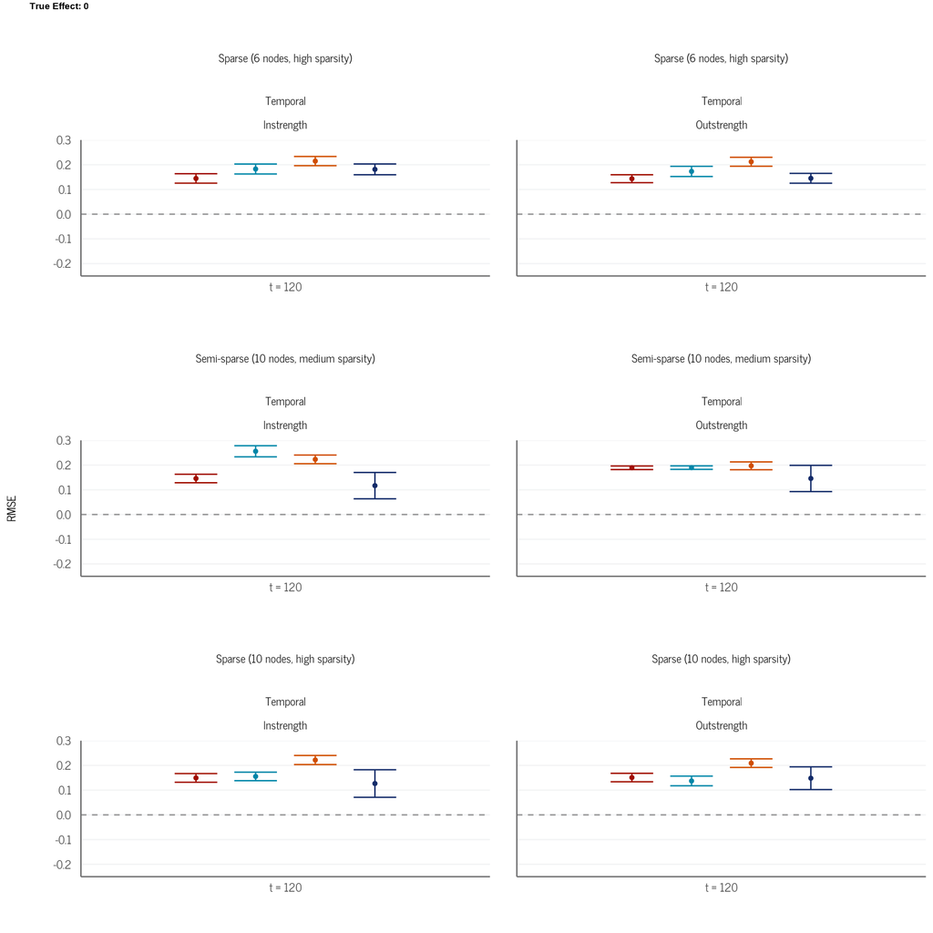

```r
processed_list <- process_data(sr_edit, "rmsereg")
plot_power_rmse_strength <- lapply(processed_list, create_regression_plot, y_label = "RMSE")
combined_plot <- cowplot::plot_grid(
  plotlist = plot_power_rmse_strength,
  ncol = 1,
  labels = c("True Effect: 0", "True Effect: 0.2", "True Effect: 0.4")
)
combined_plot
```

Plot the bias:

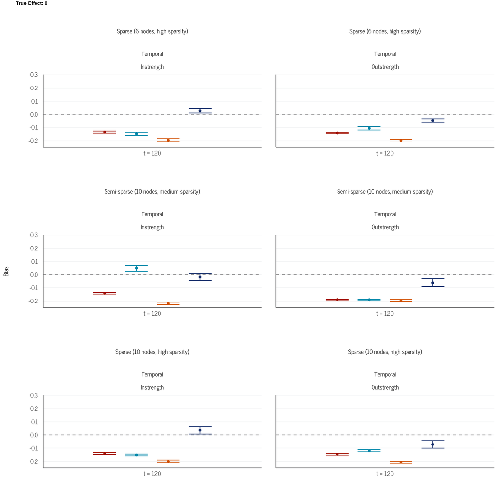

```r
processed_list <- process_data(sr_edit, "biasreg")
plot_power_bias_strength <- lapply(processed_list, create_regression_plot, y_label = "Bias")
combined_plot <- cowplot::plot_grid(
  plotlist = plot_power_bias_strength,
  ncol = 1,
  labels = c("True Effect: 0", "True Effect: 0.2", "True Effect: 0.4")
)

combined_plot
```

# 9 MCMC Diagnostics

We can now look at the Bayesian models in more detail and check if the Rhats are satisfactory, as well as if there were any divergent transitions.

First, look at Rhats for the three conditions:

```r
df_rev2 |>
  select(bmlvar_diagnostics.rhat_bmlvar_mean) |>
  rename("Mean Rhat" = bmlvar_diagnostics.rhat_bmlvar_mean) |>
  knitr::kable()
```

| Mean Rhat |
| --- |
| 1.0005037 |
| 0.9994706 |
| 1.0003614 |

Second, we tabulate divergent transitions:

```r
df_rev2|>
  select(contains("divtrans")) |>
  rename_with(~ str_remove(., "bmlvar_diagnostics."), everything()) |>
  knitr::kable(col.names = c("Mean Number of DivTrans",
                            "Sum of DivTrans",
                            "Models with Divtrans"))
```

| Mean Number of DivTrans | Sum of DivTrans | Models with Divtrans |
| --- | --- | --- |
| 6.595000 | 1319 | 60 |
| 1.200000 | 36 | 6 |
| 6.266667 | 188 | 15 |

We see that there are, on average, more divergent transitions for models with a sparse data-generating process.

**R version 4.5.1 (2025-06-13)**

**Platform:** x86_64-pc-linux-gnu

**locale:** *LC_CTYPE=en_US.UTF-8*, *LC_NUMERIC=C*, *LC_TIME=en_US.UTF-8*, *LC_COLLATE=en_US.UTF-8*, *LC_MONETARY=en_US.UTF-8*, *LC_MESSAGES=en_US.UTF-8*, *LC_PAPER=en_US.UTF-8*, *LC_NAME=C*, *LC_ADDRESS=C*, *LC_TELEPHONE=C*, *LC_MEASUREMENT=en_US.UTF-8* and *LC_IDENTIFICATION=C*

**attached base packages:** *stats*, *graphics*, *grDevices*, *utils*, *datasets*, *methods* and *base*

**other attached packages:** *lm.beta(v.1.7-2)*, *here(v.1.0.2)*, *MetBrewer(v.0.2.0)*, *pander(v.0.6.6)*, *ggh4x(v.0.3.1)*, *janitor(v.2.2.1)*, *ggokabeito(v.0.1.0)*, *showtext(v.0.9-7)*, *showtextdb(v.3.0)*, *sysfonts(v.0.8.9)*, *cowplot(v.1.2.0)*, *SimDesign(v.2.21)*, *lubridate(v.1.9.4)*, *forcats(v.1.0.1)*, *stringr(v.1.5.2)*, *dplyr(v.1.1.4)*, *purrr(v.1.1.0)*, *readr(v.2.1.5)*, *tidyr(v.1.3.1)*, *tibble(v.3.3.0)*, *ggplot2(v.4.0.0)* and *tidyverse(v.2.0.0)*

**loaded via a namespace (and not attached):** *gtable(v.0.3.6)*, *xfun(v.0.53)*, *htmlwidgets(v.1.6.4)*, *tzdb(v.0.5.0)*, *vctrs(v.0.6.5)*, *tools(v.4.5.1)*, *generics(v.0.1.4)*, *curl(v.7.0.0)*, *parallel(v.4.5.1)*, *pkgconfig(v.2.0.3)*, *R.oo(v.1.27.1)*, *RColorBrewer(v.1.1-3)*, *S7(v.0.2.0)*, *lifecycle(v.1.0.4)*, *compiler(v.4.5.1)*, *farver(v.2.1.2)*, *textshaping(v.1.0.4)*, *brio(v.1.1.5)*, *codetools(v.0.2-20)*, *snakecase(v.0.11.1)*, *htmltools(v.0.5.8.1)*, *yaml(v.2.3.10)*, *pillar(v.1.11.1)*, *R.utils(v.2.13.0)*, *sessioninfo(v.1.2.3)*, *parallelly(v.1.45.1)*, *tidyselect(v.1.2.1)*, *digest(v.0.6.37)*, *stringi(v.1.8.7)*, *future(v.1.67.0)*, *listenv(v.0.9.1)*, *labeling(v.0.4.3)*, *rprojroot(v.2.1.1)*, *fastmap(v.1.2.0)*, *grid(v.4.5.1)*, *cli(v.3.6.5)*, *beepr(v.2.0)*, *magrittr(v.2.0.4)*, *future.apply(v.1.20.0)*, *clipr(v.0.8.0)*, *withr(v.3.0.2)*, *scales(v.1.4.0)*, *timechange(v.0.3.0)*, *rmarkdown(v.2.30)*, *globals(v.0.18.0)*, *audio(v.0.1-11)*, *progressr(v.0.17.0)*, *ragg(v.1.5.0)*, *R.methodsS3(v.1.8.2)*, *hms(v.1.1.4)*, *pbapply(v.1.7-4)*, *evaluate(v.1.0.5)*, *knitr(v.1.50)*, *testthat(v.3.2.3)*, *rlang(v.1.1.6)*, *Rcpp(v.1.1.0)*, *xtable(v.1.8-4)*, *glue(v.1.8.0)*, *jsonlite(v.2.0.0)*, *R6(v.2.6.1)* and *systemfonts(v.1.3.1)*

## References

Borsboom, Denny. 2017. “A Network Theory of Mental Disorders.” *World Psychiatry* 16 (1): 5–13. https://doi.org/10.1002/wps.20375.

Epskamp, Sacha, Joost Kruis, and Maarten Marsman. 2017. “Estimating Psychopathological Networks: Be Careful What You Wish For.” *PLOS ONE* 12 (6): e0179891. https://doi.org/10.1371/journal.pone.0179891.

Hoekstra, Ria H. A., Sacha Epskamp, and Denny Borsboom. 2022. “Heterogeneity in Individual Network Analysis: Reality or Illusion?” *Multivariate Behavioral Research* 58 (4): 762–86. https://doi.org/10.1080/00273171.2022.2128020.

Kankaanpää, Reeta, Jill De Ron, Ria H. A. Hoekstra, and Riet Van Bork. 2026. “Comparing Multiple-Indicator Approaches to Account for Measurement Error in Dynamic Networks.” *Cognitive Therapy and Research*, March. https://doi.org/10.1007/s10608-026-10719-0.

Mansueto, Alessandra C., Reinout W. Wiers, Julia C. M. van Weert, Barbara C. Schouten, and Sacha Epskamp. 2023. “Investigating the Feasibility of Idiographic Network Models.” *Psychological Methods* 28 (5): 1052–68. https://doi.org/10.1037/met0000466.

Nestler, Steffen, and Sarah Humberg. 2021. “Gimme’s Ability to Recover Group-Level Path Coefficients and Individual-Level Path Coefficients.” *Methodology* 17 (1): 58–91. https://doi.org/10.5964/meth.2863.

O’Driscoll, C., S. Epskamp, E. I. Fried, R. Saunders, A. Cardoso, J. Stott, J. Wheatley, et al. 2022. “Transdiagnostic Symptom Dynamics During Psychotherapy.” *Scientific Reports* 12 (1): 10881. https://doi.org/10.1038/s41598-022-14901-8.